# Alianza Restorative Justice Case Study DRAFT Findings

Trends in suspensions, chronic absenteeism, academic achievement, and school climate before and after restorative justice in CVUSD

Advancement Project California

03/02/20

**Note the data presented in this webpage are draft results that are still being reviewed and verified. They should not be shared and are subject to change.**

- Key restorative justice campaign dates:
  - FY 2014-15: PBIS made its way onto the LCAP, a counselor was charged with getting this program into schools.
  - FY 2015-16: PBIS was further expanded by beginning the PBIS Teacher Lead model, which began first incorporating RJ at the elementary school level. Assistant Principals were also required to take professional development on PBIS.
  - 2016 Year of Bobby Duke pilot?
  - FY 2016-17: This was meant to be THE YEAR for RJ, with the District proposing to hire four part-time classified assistants to implement RJ at middle schools, a Restorative Practice Coordinator, and hold an RJ Family Conference but that did not happen due to budget constraints. Instead the PBIS/RJ Teacher Lead stipend model was more formally adopted. CVUSD did create an RJ Task Force that met several times but there was no description of what they discussed in the LCAP.
  - FY 2017-18: By this year CVUSD defaulted to doing the minimum by simply sticking with the PBIS/RJ Teacher Lead stipends.
  - FY 2018-19: In this year CVUSD continued their stipend program and held staff development days to provide RJ professional development led by CCEJ. CA Learning Communities for School Success Program Grant began.
  - FY 2019-20: It appears as if this year will be a continuation of FY19.

# DRAFT Findings

## Context Setting

**High use of suspensions for discipline in CVUSD middle schools at the start of the RJ campaign**

- In 2013-14, schools serving middle school students in CVUSD suspended 9.9% of students compared to a 5.5% suspension rate at CVUSD high schools.
- Bobby Duke, the school that first piloted RJ, had the highest suspension rate out of all middle schools suspending 13.5% of students in 2013-14.
- Prior to the year the RJ campaign started, many middle schools were also experiencing a higher rate of suspensions for willful defiance compared to averages for high schools and middle schools. West Shores High, Cahuilla Desert Academy Junior High, and Bobby Duke all suspended more than 5% of students for willful defiance in 2012-13 with West Shores suspending 9.1% of students for willfull defiance. Willful defiance suspension rates sharply decreased in 2013-14-the year the campaign launched.
- In 2014-15, 60% of school staff who took the School Climate Staff Survey agreed or strongly agreed that their school enforced zero tolerance policies.

**Low expectations and poor relationships between students and teachers**

- In 2014-15, only 48% of school staff said most or nearly all adults at the school believed every student could be a success.

**Lower achievement among middle schools in CVUSD**

## Outcomes

**Changes in suspensions following Bobby Duke pilot**

- Following an increase in suspensions in 2015-16 (15.6% suspension rate), Bobby Duke had a decrease in suspensions in 2016-17 after the pilot (12.2%).

**Changes in school discipline and suspensions following RJ expansion to all middle schools**

- Following CVUSD incorporating RJ Teacher Lead stipends in 2016-17, suspensions for willful defiance nearly dropped to 0 in 2017-18 and 2018-19 for both middle schools and high schools. In 2018-19, CVUSD also had implemented staff development days and received the CA Learning Communities for School Success grant.
- As a whole the suspension rate among CVUSD middle schools decreased in 2018-19 closer to the rate among high schools. While suspensions were at a high of 12.5% in 2017-18 in schools serving grades 7-8, they decreased to 9.9% in 2018-19. The high school suspension rate in 2018-19 was 7.9%.
- While suspensions were still high in 2017-18 among middle schools, the School Climate staff survey shows changes in staff. Only 44% of staff in middle schools agreed or strongly agreed their school enforces zero tolerance policies compared to 60% in 2014-15.
- Nearly 2 in 3 staff (63%) in middle schools agreed or strongly agreed their school encourages students to understand how others think and feel compared to 55% in 2014-15.
- NOTE: Increases in suspensions in 2017-18 may be partially driven by suspensions for drug-use. For instance, in 2017-18, there was a sharp increase in the number of suspensions related to use, sale, or posession of illicit drugs at Bobby Duke.

**Changes in staff perceptions of students**

- Nearly 3 in 4 (72%) of school staff agreed or strongly agreed that adults at their school believe every student can be a success in 2017-18–a sharp increase from 2014-15 where only 48% of staff agreed with the highest two categories.
- 85% of middle school parents in 2017-18 agreed or strongly agreed that their school has adults that really care about students.

**Parent perceptions and input**

- 3 in 4 parents (77%) agreed or strongly agreed that their school seeks input of parents before making important decisions.

## Challenges

**Implementation and impact varies by school.**

- Ups and downs in suspension rates seen throughout the RJ campaign are due to a variety of factors, including changes in administrators or teachers or trends in use of controlled substances among students. While Bobby Duke and Tory Canyon had decreases in suspensions in 2018-19, West Shores and Cahuilla Desert Academy had slight increases in suspension rates.

**Suspension rates in middle schools still remain higher than suspension rates at high schools and academic achievement is lower**

- In 2018-19, the disparity in suspension rates between middle schools and high schools decreased, but middle schools still on average are suspending more students than high schools (9.9% versus 7.9%).
- ELA and Math scores for schools serving grades 7-8 remain behind scores for high school students. With ELA scores among 7th and 8th graders further behind.

**Chronic absenteeism remains high in middle schools and even higher in high schools.**

**Greater opportunity for school climate improvements and data collection**

- The school climate data available show greater opportunities for improvement in school climate. Slightly fewer teachers agreed or strongly agreed that adults at their school treat students with respect in 2017-18 (70%) compared to 2014-15 (76%).
- Based on limited data, most parent perceptions of school climate, including student/teacher relationships and parent input in school decisions, have not improved significantly since the RJ campaign started.
- School climate surveys should be consistently administered. While the parent school climate survey was administered in 2014-15, only 18 middle school parents took it. Similarly, only 24 teachers took the survey in 2014-15.

# School Discipline Measures

## Suspension Rate

### Middle School Suspensions between 2011-12 and 2018-19

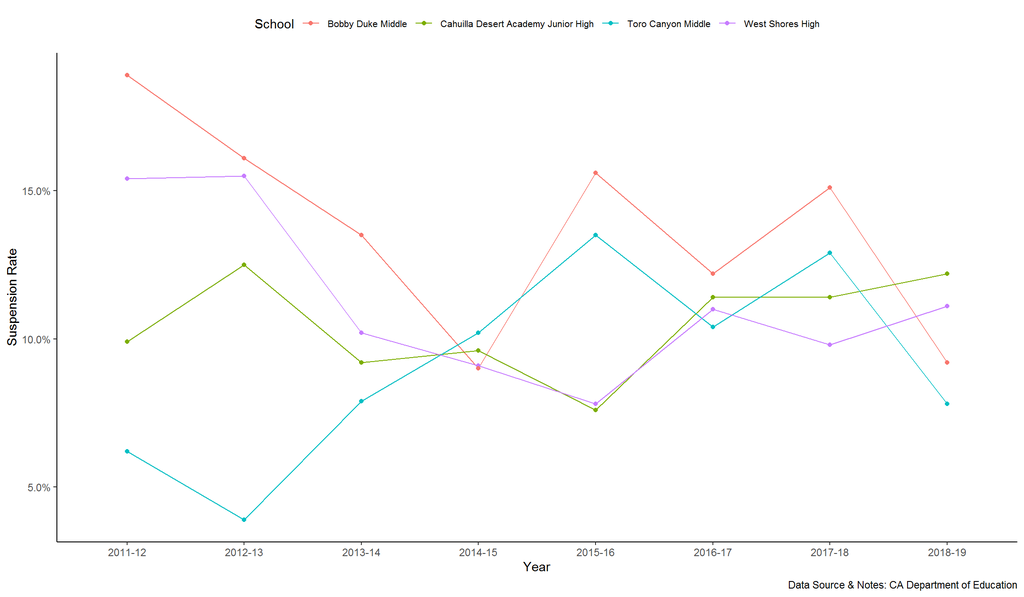

### Bobby Duke’s Suspension Rate Compared to Other Middle Schools (Pre/Post Pilot)

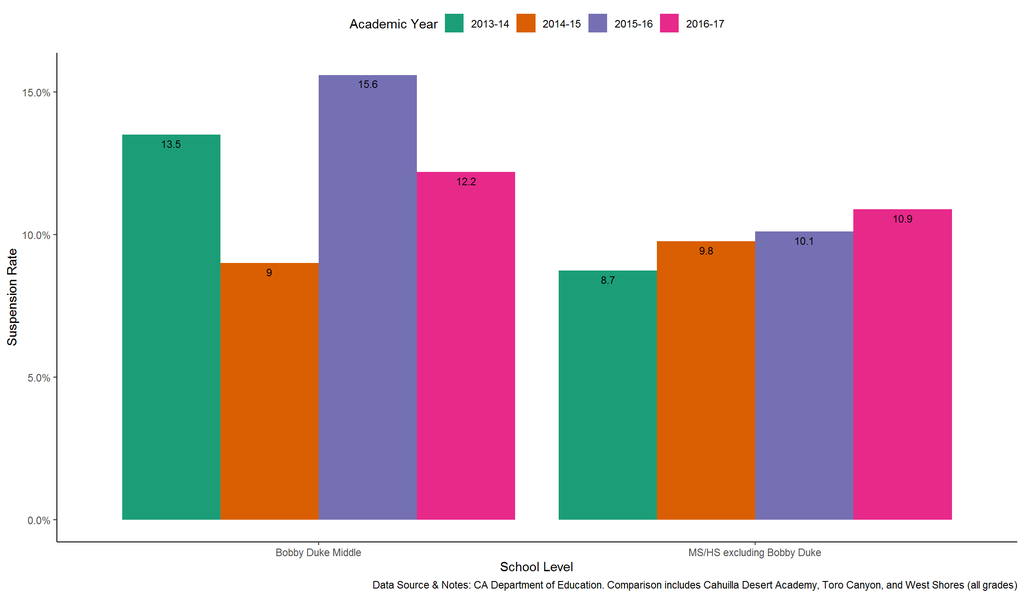

### Middle Schools’ Total Suspension Rate compared to High Schools (Pre/Post RJ Expansion)

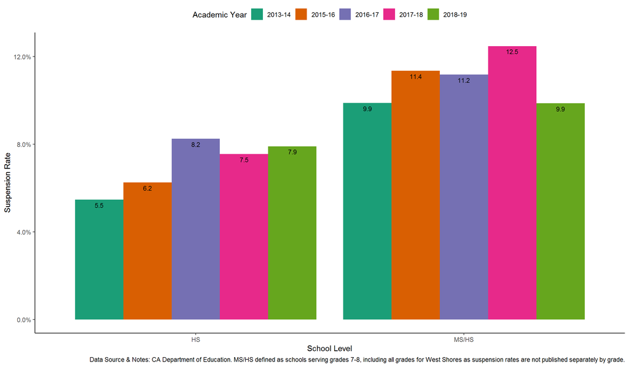

## Suspensions for Defiance

### Middle School Suspensions for Defiance between 2011-12 and 2018-19

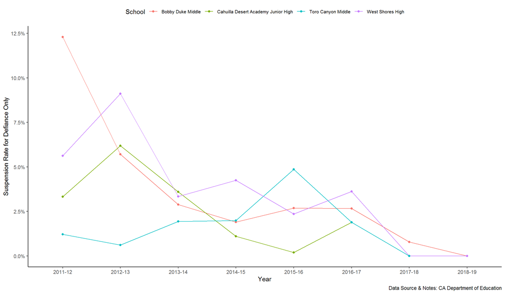

### Bobby Duke’s Defiance Suspension Rate Compared to Other Middle Schools (Pre/Post Pilot)

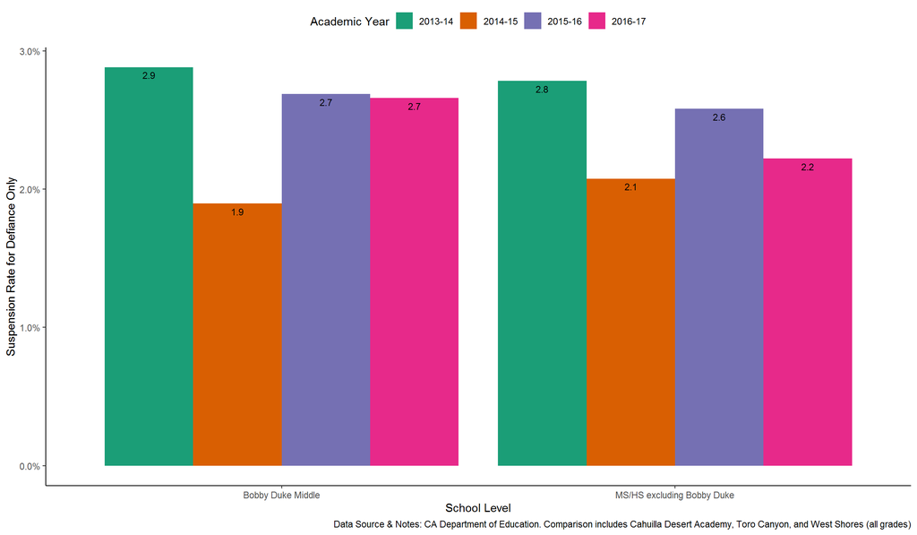

### Middle Schools’ Total Suspension Rate for Defiance compared to High Schools (Pre/Post RJ Expansion)

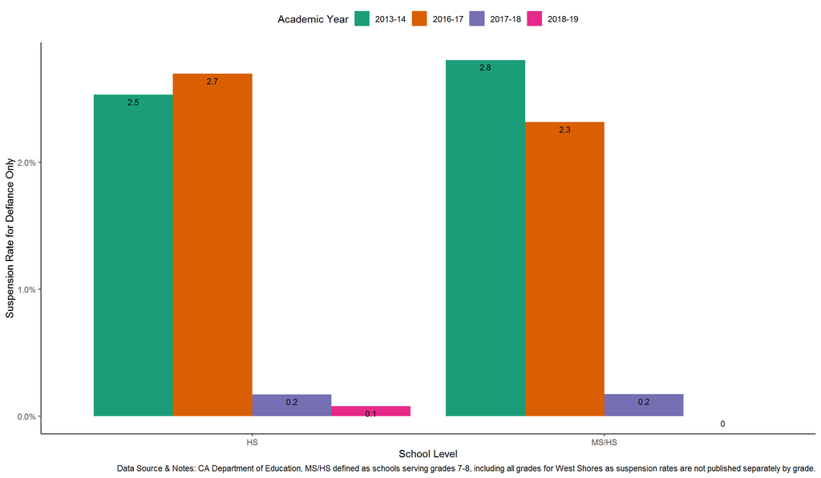

## Teacher Perceptions of Discipline

### School enforces zero tolerance policies

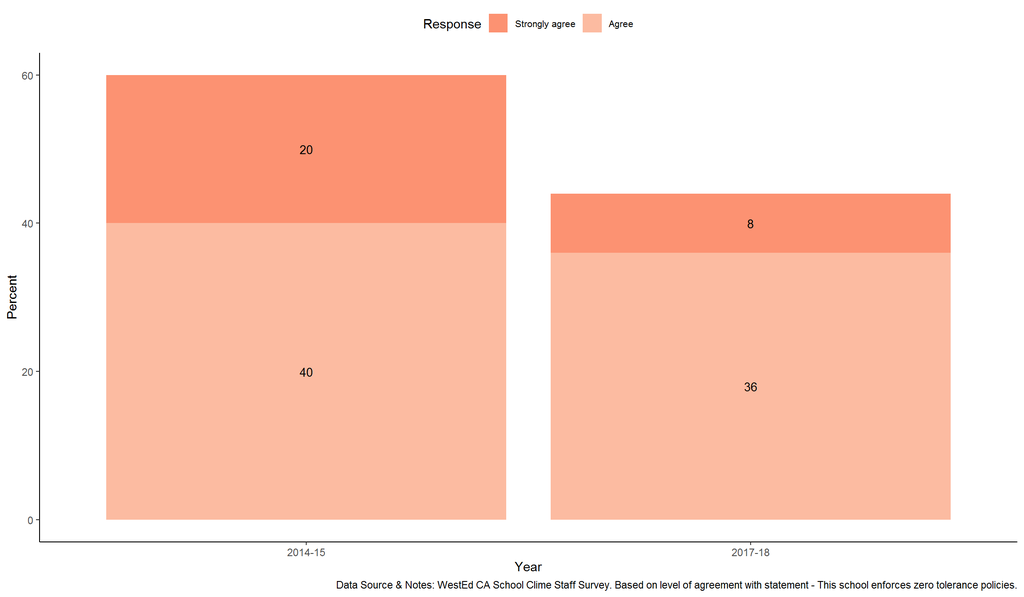

### School encourages students to understand how others think and feel

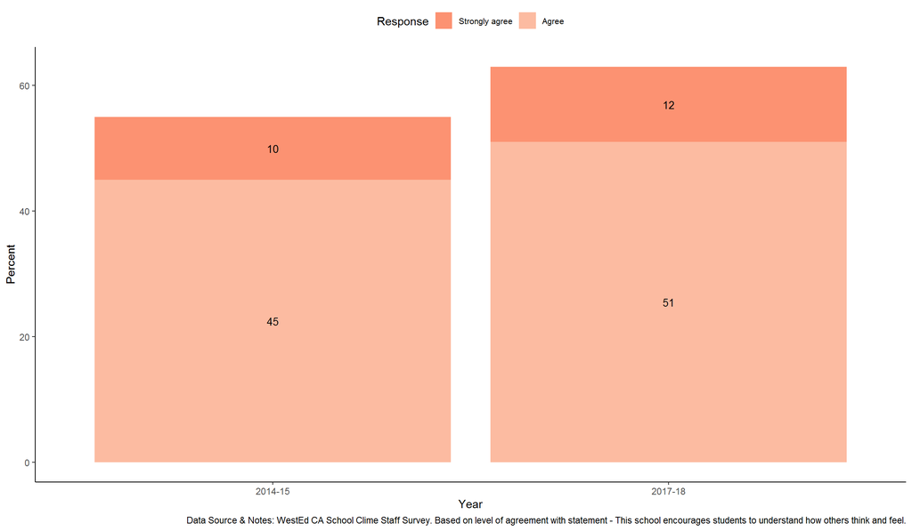

# Teacher Relationship Measures

## Teacher/Student Relationships (MS)

### Adults at this school believe every student can be a success

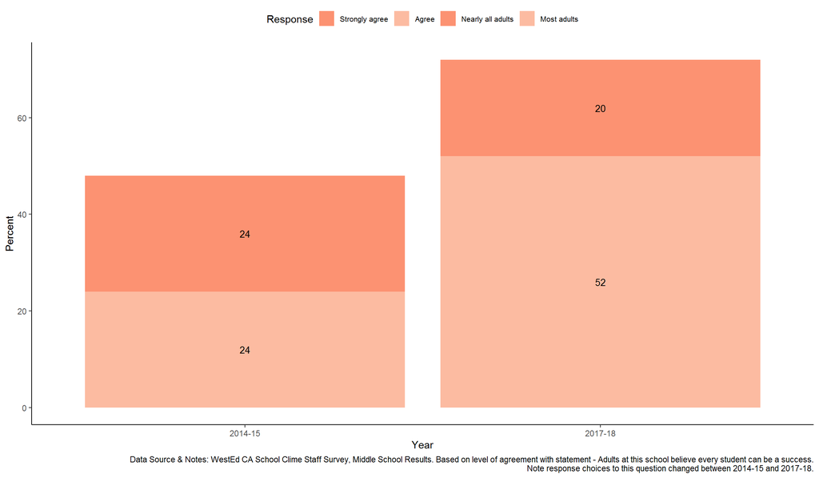

### Adults at this school treat students with respect

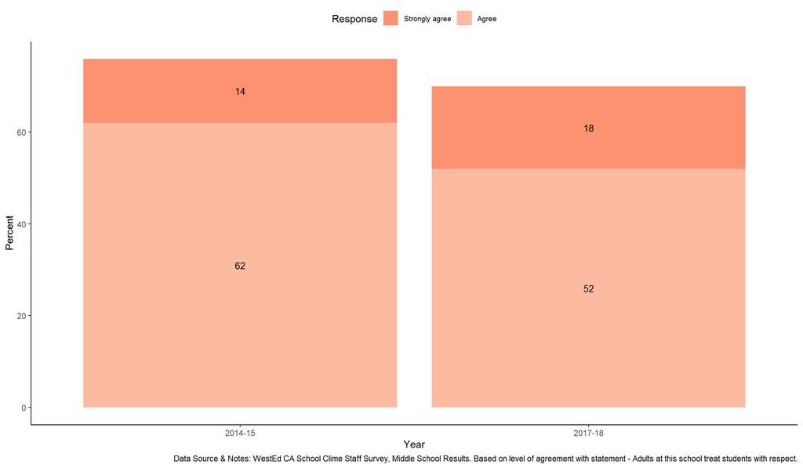

### This school has adults that care about students

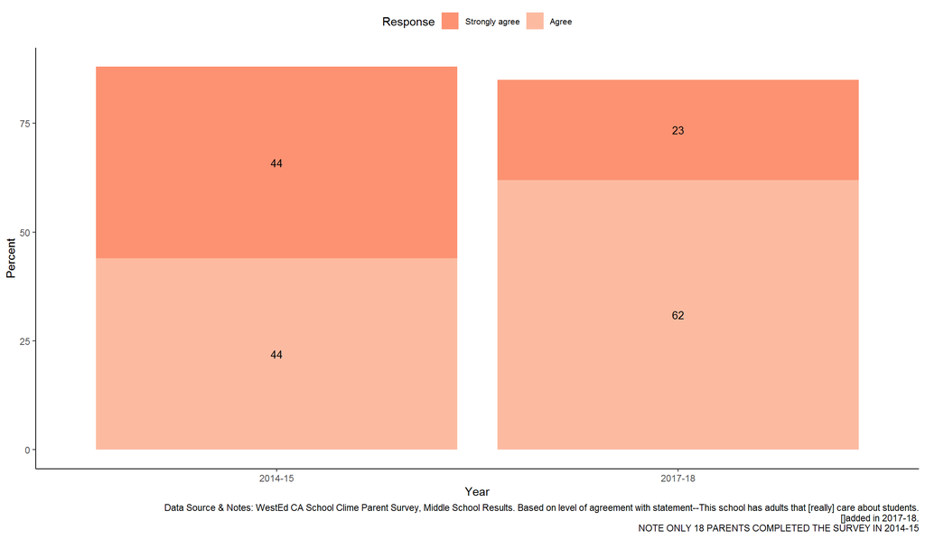

# Parent Measures

## Parent Input (MS)

### This school seeks the input of parents

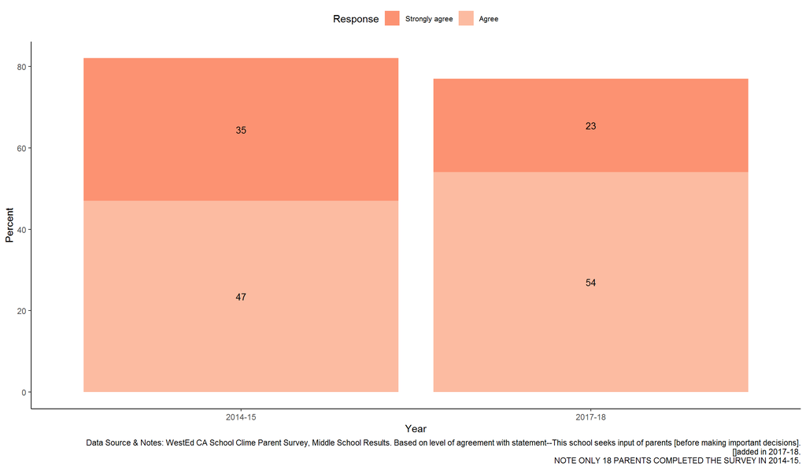

# Academic Achievement Measures

## ELA Achievement

### Middle School ELA Achievement between 2015-2019

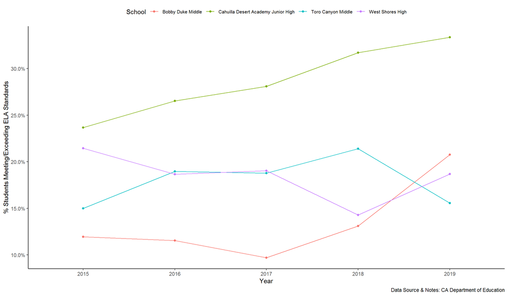

### Bobby Duke ELA Achievement Compared to Other Middle Schools (Pre/Post Pilot)

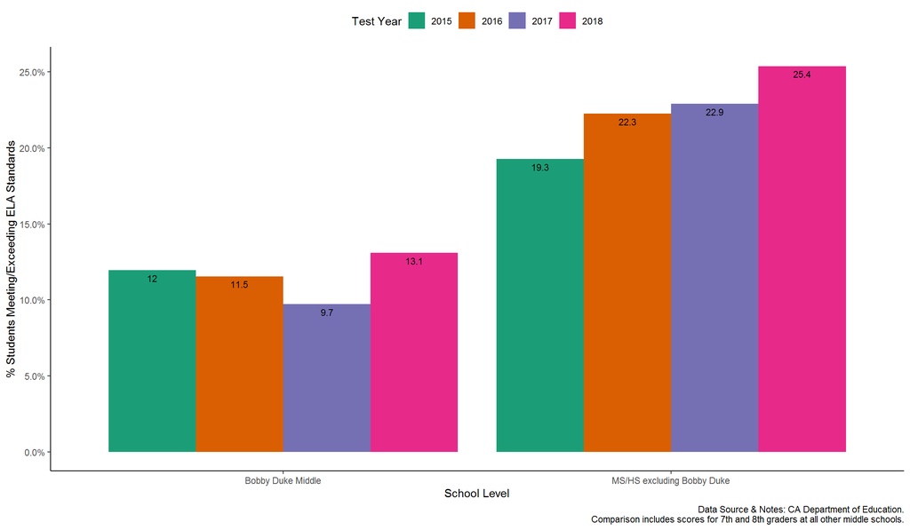

### Middle School ELA Achievement compared to High Schools (Pre/Post RJ Expansion)

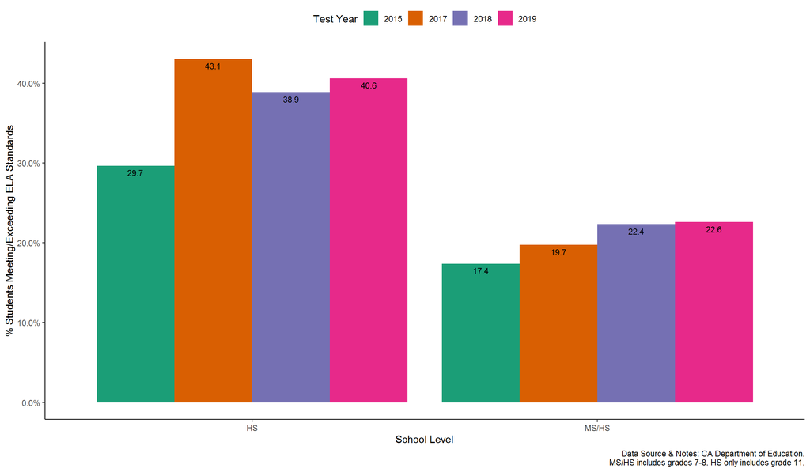

## Math Achievement Trends

### Middle School Math Achievement between 2015-2019

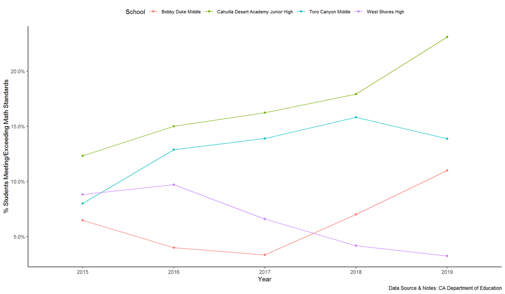

### Bobby Duke Math Achievement Compared to Other Middle Schools (Pre/Post Pilot)

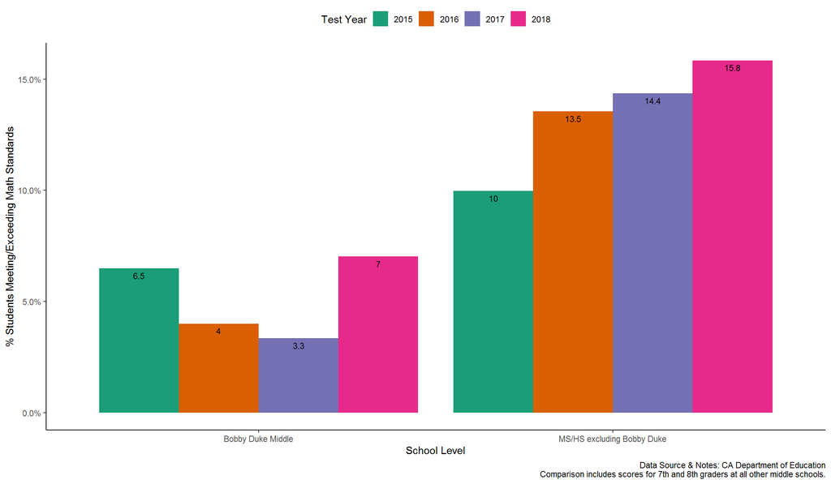

### Middle School Math Achievement compared to High Schools (Pre/Post RJ Expansion)

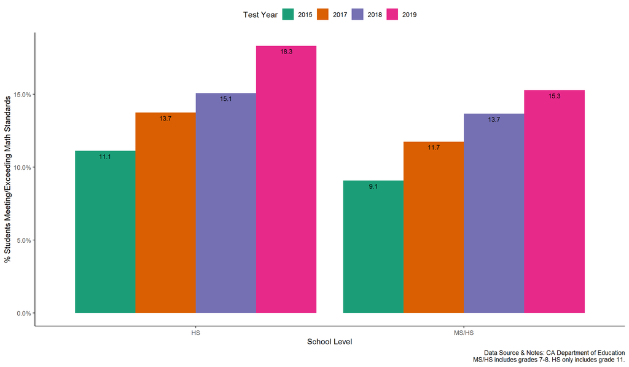

# Other Measures Run

## Chronic Absenteeism Rate

### Middle School Chronic Absenteeism Rates between 2016-17 and 2018-19

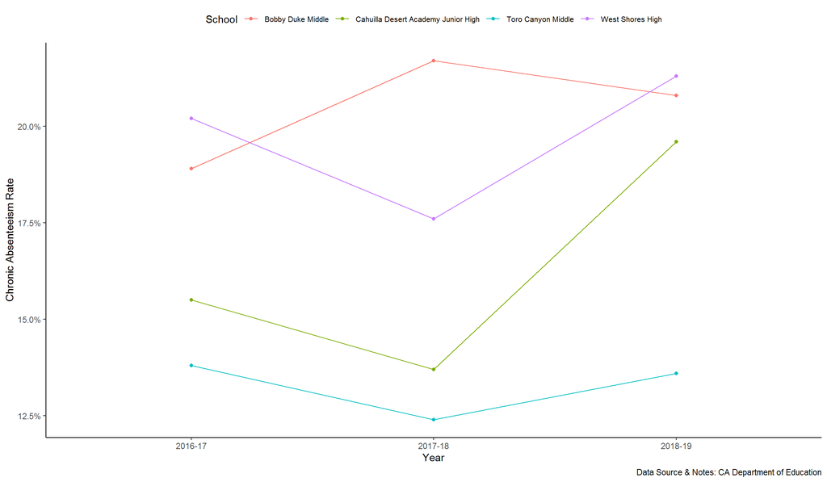

### Middle Schools’ Chronic Absenteeism Rate compared to High Schools (Pre/Post RJ Expansion)

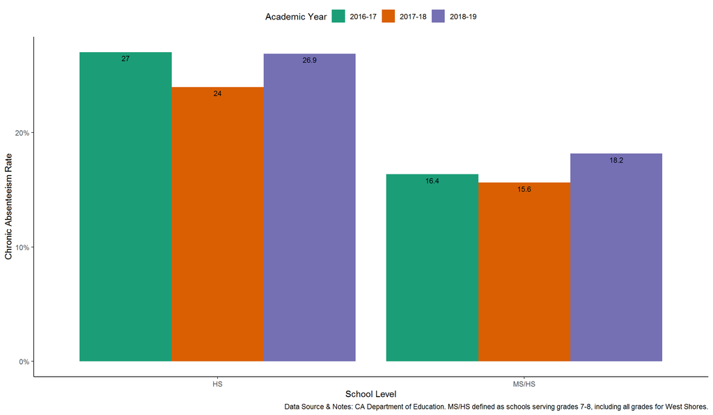

## Suspensions for Illicit Drugs Trends

### All Middle Schools

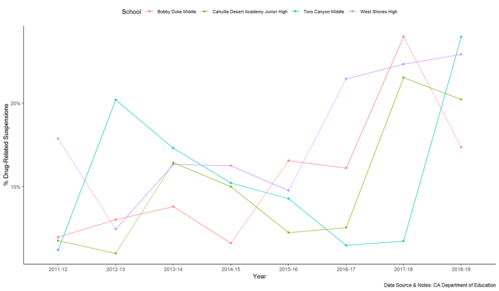

### Bobby Duke

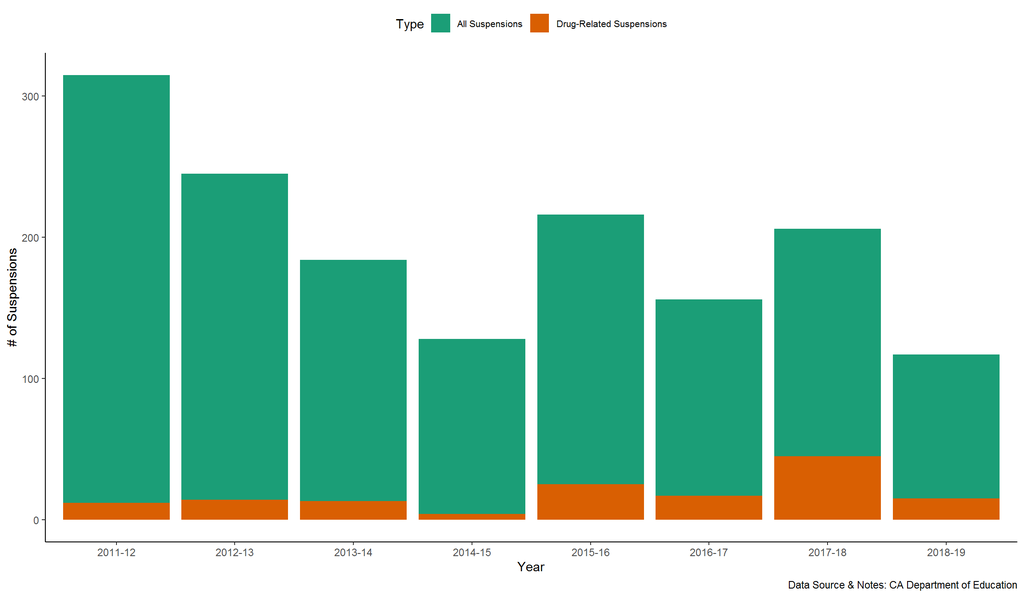

### West Shores

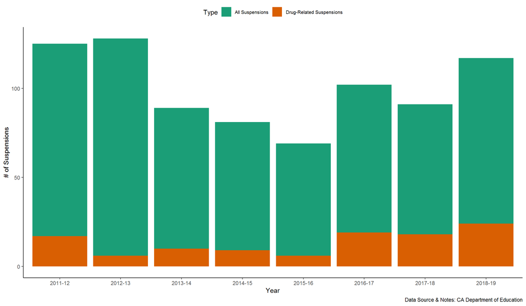

## Bobby Duke ELA & Math Trends

### ELA

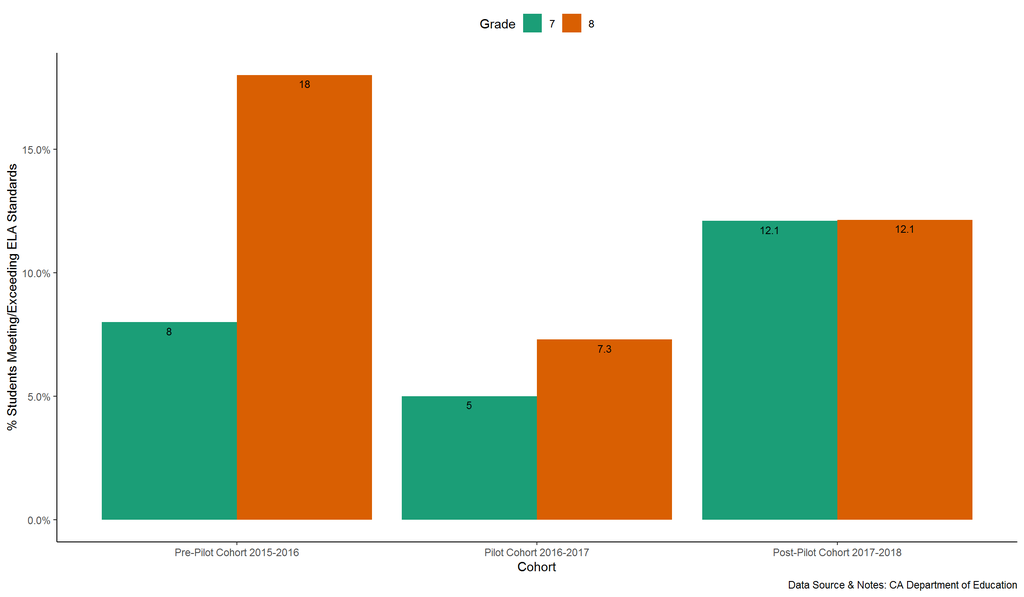

### Math

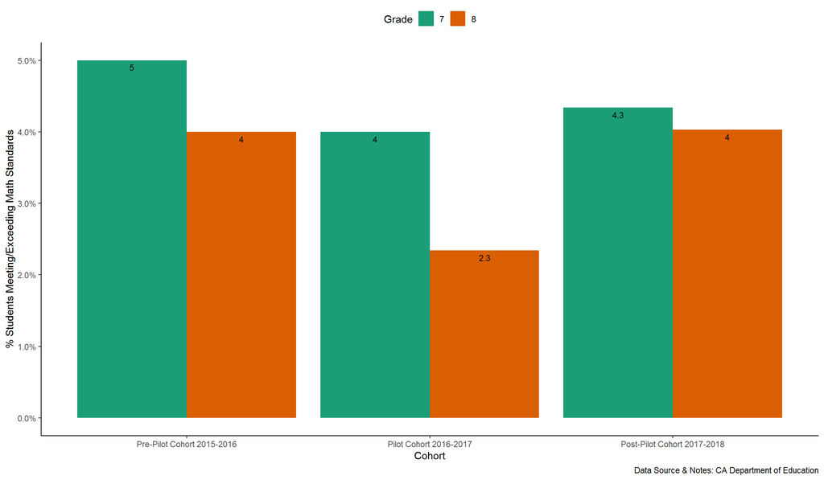